# 시계열 데이터

## 시계열 데이터의 특징

### 구성 요소

1. **추세(Trend) : 증가하거나 감소하는 추세가 꾸준히 지속되는 경향**
2. 순환(Cycle) :
3. **계절(Seasonaliy) : 주기적으로 반복되는 파형, 경향**
4. 불규칙성 : 우상향, 우하양

> Facebook의 Prophet 모델 : 추세와 계절을 인용하여 예측하는 알고리즘이 있음 $$ y(t) = g(t) + h(t) + s(t) + et \\ g(t) : trend, s(t) : seasonality, h(t) : hoildays $$

### 시계열 데이터의 이상은 무엇인가?

- Outlier : 트래픽이 갑자기 치솟는 `스파이크`를 보일 때
- Temporal changes(계절과 연관) : 특정 규칙된 패턴에서 짧은 기간동안 0 이나 0에 가까운 관측값이 나올 때 그 구간을 의미한다.
- Level shifts(계절과 연관) : 반복적으로 파형이 나와야하는데, 주기성을 잃어버리는 구간을 의미한다.

### 그러면 어떤 것이 이상(Anomaly)인가?

**이상치에 대한 정의는 다 다르다.**

Q1. 실측치가 예측보다 낮을 떄도 이상이라고 정의하나?

- 통신망 장치에서 다중화와 부하 분산이 잘 구축되어 있기에, 너무 낮은 값은 문제라고 볼 수 있음 (기기의 신뢰도)
- 특정 장비의 트래픽 저하는 다른 장비의 트래픽 증가로 연관지어 볼 수 있어 이상치라고 볼 수 있음 (트래픽 분산)

Q2. 이상 범주 임계치(Threshold)는 어떻게 정의할까?

- 시간 흐름에 따라 손실 값을 계속 계측하여 **동적**으로 정의하는 것이 타당함

## 시계열 데이터의 전처리

### pandas를 이용한 데이터 정보 획득

columns : enb_cell_id, dt, hh, dl_bler, ul_bler

### 데이터 통합

1. id_df['enb_cell_id'] = df_0['enb_cell_id']
2. drop_duplicates('enb_cell_id').reset_index()를 통해 통합

> **통합할 때 동일 테이블 내 고유 레이블을 유지하는게 중요하겠네**

```python
# 예시: 'enb_cell_id' 컬럼을 기준으로 중복 제거 및 통합
df_unique = df.drop_duplicates(subset=['enb_cell_id']).reset_index(drop=True)
```

### 고유레이블 유지

- id-수집날짜-시간 형태로 고유한 레이블 값을 지닌 칼럼으로 통합

```python
def labelmerge(df):
    new_label =[]
    for i in range(len(df)):
        id = df['enb_cell_id'][i] + "-"+str(df['dt'][i]) + '-'+str(df['hh'][i])
        new_label.append(id)
    df['New_col'] = new_label
    return df
```

## 결측값처리의 방법

### 1. 삭제

- 단일값 삭제
- 행 삭제
- 열 삭제

> 데이터를 손실하기에 잘 사용되지 않음

### 2. 대체

- 시계열이 아닐 때
  - 통계량, 중앙값, 평균으로 대체
  - 상수 처리
- 시계열일 때
  - Forward Fill (전진)
  - Back Fill (후진)
  - Linear interpolation (보간법)
  - spline interploation
- 시계열 진보
  - KNN
  - MICE

## 보간법

- 보간법이란? 데이터 분석에서 이산형 집합의 범위에 기반하여 새로운 데이터 포인트를 만들거나 찾는 추정의 한 유형이다.

### Scipy 모듈을 이용한 결측값 보강

- from scipy import interploate
1. Privious value
- 앞선 값으로 동일하게 진행
2. Piecewise constant interpolation
- 가장 가까운 값을 고름
3. Liner
- 점과 점 사이의 직선으로 찾기
4. Spline
- 점과 점 사이의 곡선으로 찾기

### 언제 스플라인이고 언제 리니어인가?

- 추세와 계절성을 보고 판단한다!

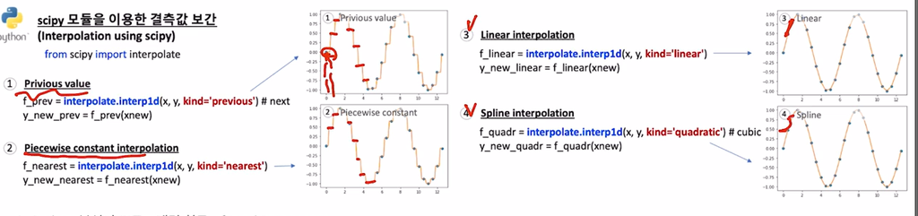

### 보간법 코드 구현

- df[col].interpolate() # linear
- df[col].interpolate(method='polynomial', order=2 # 3차도 가능)

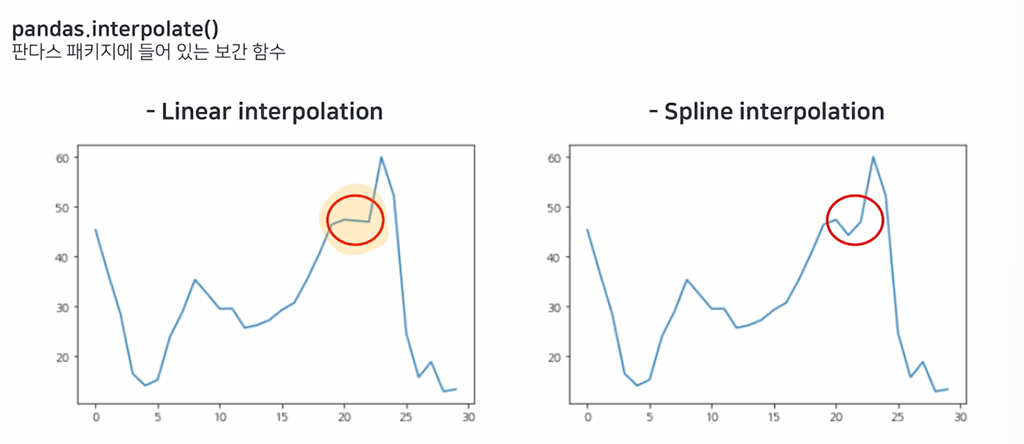

> 데이터의 스케일이 다를 때, 분석이 어려움!

### 정규화(normalize)

- 가장 큰값을 1로 가장 작은 값을 0으로 바꾸기
- 범위가 축소된 채로 데이터의 분포를 보여줌

### 표준화(standardize)

- 정규분포 N(0,1)로 평균과 표준편차를 범위에 조정
- 균등한 범위안에 데이터의 분포를 보여줌

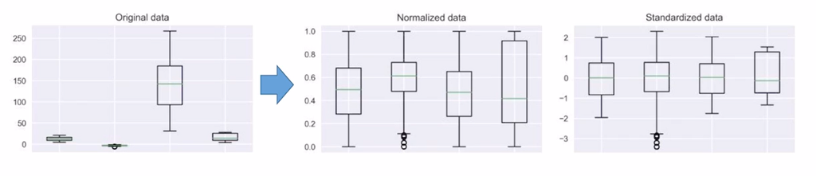

### 스케일러

sklearn의 피처 스케일링 함수 두 가지

- StandardScaler
- MinMaxScaler

df_dl_prb = df_neww[col].values.reshape(-1,1)

> **2차원의 데이터만 가질 수 있도록 reshape 필수!**

```python
from sklearn.preprocessing import MinMaxScaler
scaler_2 = MinMaxScaler()
df_scaled_2 = scaler_2.fit_transform(df_dl_prb)
```